# MACHINE LEARNING - CLASSIFICAÇÃO COM NAIVE BAYES E ÁRVORE DE DECISÃO

Autor

João Ricardo F. de Lima

Data de Publicação

15 de abril de 2024

# Classificação com Naive Bayes

[^1] **Probabilidade** é um número entre 0 e 1, que captura as chances de um evento ocorrer, dado um conjunto de evidências. O algoritmo Naive Bayes, como o próprio nome diz, está baseado no **Teorema de Bayes**. Ele utiliza um conjunto de treino de modo a calcular a probabilidade de cada resultado com base nos valores de variáveis conhecidas. Assim, quando o algoritmo é aplicado a dados não rotulados, ele utiliza as probabilidades observadas para prever a qual classe mais provável pertence aquele dado.

**Teoria de probabilidade bayesiana**: a probabilidade estimada de um evento é baseada na evidência disponibilizada por várias tentativas (*trials* ou oportunidades para que o evento ocorra).

Exemplo:

- **Evento de interesse**: candidato ganhar eleição;
- **Tentativa**: eleição presidencial.
- **Evento de interesse**: texto é um spam;
- **Tentativa**: comentário em vídeo do YouTube.

## Como calcular a probabilidade?

Probabilidade de um evento:

$$P=\frac{\text{Nº de tentativas em que o evento ocorreu}}{\text{Nº total de tentativas}}$$

A probabilidade de um evento será estimada a partir dos dados observados dividindo-se o números de tentativas onde o evento ocorreu pelo número total de tentativas. Por exemplo, se choveu em 3 dos 10 dias com condições atmosféricas similares, a probabilidade de chover hoje será de $\frac{3}{10} = 0,30 = 30\%$. De forma similar, se 10 dos 50 emails recebidos forem considerados como *spam*, a probabilidade de um email recebido ser um *spam* será de 20%.

Como consequência, a probabilidade de não chover será de 70% e a probabilidade de um email não ser um spam será de 80%. Isto porque, estamos tratando de eventos que são **mutualmente exclusivos**, i.e., não podem podem ocorrer ao mesmo tempo.

Sob certas circunstâncias, porém, pode-se estar interessados em eventos não mutualmente exclusivos. Se certos eventos ocorrem com o evento de interesse, nós pode-se usá-lo para fazer previsões.

Por exemplo, no caso do spam, um segundo evento pode ser *emails contendo a palavra Viagra*. Na maioria dos casos, essa palavra aparecerá em emails considerados como spam. Sua presença em um email recebido é uma forte evidência de que a mensagem em questão é um spam.

Sabe-se que 20% de todas as mensagens são spam e 5% de todas as mensagens contém a palavra Viagra. Se está interessado, então, em definir a probabilidade de que $P(spam)$ e $P(Viagra)$ ocorram ao mesmo tempo, isto é, $P(spam \cap Viagra)$.

Calcular $P(spam \cap Viagra)$ depende da **probabilidade conjunta** de dois eventos ou como a probabilidade de um evento está relacionada com a probabilidade de outro evento. Se dois eventos são totalmente não relacionados, eles são chamados de **eventos independentes**.

Os eventos podem ocorrer ao mesmo tempo, mas se eles são independentes significa dizer que saber a probabilidade de um evento ocorrer não provê qualquer informação sobre o outro evento.

Se todos os eventos são independentes, é impossível prever um observando outro. Em outras palavras, **eventos dependentes** são a base da modelagem preditiva.

De forma geral, para eventos independentes, tem-se:

$$P(A \cap B) = P(A)*P(B)$$

Sabe-se, porém, que o cálculo acima está incorreto porque $P(spam)$ e $P(Viagra)$ não são independentes.

O relacionamento entre eventos dependentes pode ser descrito utilizando o **Teorema de Bayes**:

$$P(A|B) = \frac{P(A \cap B)}{P(B)}$$

Essa formulação provê um meio de pensar sobre como rever a probabilidade estimada de um evento à luz da evidência disponibilizada por outro evento. A notação $P(A|B)$ deve ser lida como *a probabilidade do evento A ocorrer, dada a ocorrência do evento B*. Isso é conhecido como **probabilidade condicional**.

Dado que $P(A \cap B) = P(B \cap A)$, pode-se reescrever o Teorema de Bayes da seguinte forma:

$$P(A|B) = \frac{P(A \cap B)}{P(B)} = \frac{P(B|A)P(A)}{P(B)} = \frac{\text{Probabilidade} \times \text{Probabilidade a priori}}{\text{Probabilidade marginal}}$$

Esse é o formato mais tradicional em que o teorema é apresentado.

- **Probabilidade a priori** $P(A)$: sem abrir o email, a melhor estimativa é a probabilidade anterior, ou seja, a probabilidade do email ser um spam.
- **Probabilidade** $P(B|A)$: investigando emails spam anteriores, é possível calcular a proporção em que o termo viagra aparece, constituindo evidência adicional conhecida como *probabilidade*.
- **Probabilidade marginal** $P(B)$: é a probabilidade de que o termo viagra apareça em um email.

**Tabela de frequência**:

| Classificação | Sim | Não | Total |
| --- | --- | --- | --- |
| Spam | 4 | 16 | 20 |
| Não Spam | 1 | 79 | 80 |
| **Total** | **5** | **95** | **100** |

**Tabela de probabilidades**:

| Classificação | Sim | Não | Total |
| --- | --- | --- | --- |
| Spam | 4/20 | 16/20 | 20/100 |
| Não Spam | 1/80 | 79/80 | 80/100 |
| **Total** | **5/100** | **95/100** | **100** |

- $P(\text{Viagra}=\text{Sim}|\text{Spam}) = 4/20 = 20\%$ (probabilidade de ter o termo viagra dado que é spam);
- $\frac{P(\text{Viagra}|\text{Spam}) \times P(\text{Spam})}{P(\text{Viagra})} = \frac{(4/20) \times (20/100)}{(5/100)} = 80\%$ (probabilidade a posteriori ser spam dado a presença do termo viagra). Com efeito, qualquer mensagem que contiver o termo Viagra deve ser filtrada.

Sim = termo “viagra” presente no email / Não = termo “viagra” não presente no email.

## O algoritmo Naive Bayes

“Naive” se refere a premissa ingênua em relação aos dados, assumindo as variáveis são igualmente importantes e independentes para classificar um evento de interesse.

**Pontos fortes**:

- Simples, rápido e bastante efetivo
- Trabalha bem com ruídos e valores faltantes
- Requer poucas observações para treino
- Fácil obtenção da probabilidade estimada para previsão

**Pontos fracos**:

- Baseia-se numa suposição frequentemente defeituosa de características igualmente importantes e independentes
- Não é ideal para conjuntos de dados com muitas variáveis numéricas
- As probabilidades estimadas são menos confiáveis do que as classes preditas

Podemos generalizar o algoritmo de classificação Naive Bayes a partir da seguinte fórmula:

$$P(C_{k}|x_{1},...,x_{n}) = \frac{1}{Z} p(C_{k}) \prod_{i=1}^{n} p(x_{i}|C_{k})$$

Isto é, a probabilidade do nível $k$ da classe $C$, dadas as evidências providas pelos recursos $x_{n}$ será igual aos produtos das probabilidades de cada pedaço de evidência condicionada aos níveis das classes, a probabilidade anterior do nível da classe e um fator $\frac{1}{Z}$, que converte os valores de possibilidades para probabilidades.

# Exemplo Didático com a Base de dados íris

É um conjunto de dados multivariados introduzido pelo estatístico e biólogo britânico Ronald Fisher em seu artigo de 1936, “O uso de múltiplas medições em problemas taxonômicos, como um exemplo de análise discriminante linear”. Às vezes, é chamado de conjunto de dados da íris de Anderson porque Edgar Anderson coletou os dados para quantificar a variação morfológica das flores da íris de três espécies relacionadas. Duas das três espécies foram coletadas na Península de Gaspé, “todas do mesmo campo, colhidas no mesmo dia e medidas ao mesmo tempo pela mesma pessoa com a mesma aparelho”. O conjunto de dados consiste em 50 amostras de cada uma das três espécies de Iris ( Iris setosa, Iris virginica e Iris versicolor). Quatro variáveis foram medidas em cada amostra: o comprimento e a largura das sépalas e pétalas, em centímetros. Com base na combinação dessas quatro características, Fisher desenvolveu um modelo discriminante linear para distinguir as espécies umas das outras (Fonte: https://pt.wikipedia.org/wiki/Conjunto_de_dados_flor_Iris).

```r
# Carrega os pacotes
library(e1071)
library(caTools)
library(caret)

# Dividindo (split) os dados em
# Treino (training) e teste (test)
split <- sample.split(iris, SplitRatio = 0.7)
train_cl <- subset(iris, split == "TRUE")
test_cl <- subset(iris, split == "FALSE")

# Padronizaçao dos dados
train_scale <- scale(train_cl[, 1:4])
test_scale <- scale(test_cl[, 1:4])

# Estimando o Naive Bayes Model
# com os dados de treino
set.seed(120)  # Configurando a semente
classifier_cl <- naiveBayes(Species ~ ., data = train_cl)

# Previsão com os dados de teste
y_pred <- predict(classifier_cl, newdata = test_cl)

# Confusion Matrix
cm <- table(test_cl$Species, y_pred)
cm
```

```
            y_pred
             setosa versicolor virginica
  setosa         20          0         0
  versicolor      0         20         0
  virginica       0          3        17
```

```r
# Avaliação do Modelo
confusionMatrix(cm)
```

```
Confusion Matrix and Statistics

            y_pred
             setosa versicolor virginica
  setosa         20          0         0
  versicolor      0         20         0
  virginica       0          3        17

Overall Statistics

               Accuracy : 0.95
                 95% CI : (0.8608, 0.9896)
    No Information Rate : 0.3833
    P-Value [Acc > NIR] : < 2.2e-16

                  Kappa : 0.925

 Mcnemar's Test P-Value : NA

Statistics by Class:

                     Class: setosa Class: versicolor Class: virginica
Sensitivity                 1.0000            0.8696           1.0000
Specificity                 1.0000            1.0000           0.9302
Pos Pred Value              1.0000            1.0000           0.8500
Neg Pred Value              1.0000            0.9250           1.0000
Prevalence                  0.3333            0.3833           0.2833
Detection Rate              0.3333            0.3333           0.2833
Detection Prevalence        0.3333            0.3333           0.3333
Balanced Accuracy           1.0000            0.9348           0.9651
```

## **Exemplo de classificação textual com dados reais**

Abaixo é descrito a aplicação do modelo *Naive Bayes* para um problema de classificação com dados reais.

O objetivo é classificar comentários de um vídeo no YouTube como “spam” ou “não spam”. O vídeo foi publicado na plataforma em 2010 e está intitulado como “*Eminem - Love The Way You Lie ft. Rihanna”*. Os comentários (uma amostra) estão armazenados no conjunto de dados [YouTube Spam Collection](https://archive.ics.uci.edu/dataset/380/youtube+spam+collection) (arquivo `Youtube04-Eminem.csv`) e apresentam estrutura de dados textual.

A tabela abaixo mostra as primeiras linhas da tabela de dados brutos:

| COMMENT_ID | AUTHOR | DATE | CONTENT | CLASS |
| --- | --- | --- | --- | --- |
| z12rwfnyyrbsefonb232i5ehdxzkjzjs2 | Lisa Wellas |  | +447935454150 lovely girl talk to me xxx | 1 |
| z130wpnwwnyuetxcn23xf5k5ynmkdpjrj04 | jason graham | 2015-05-29 02:26:10.651 | I always end up coming back to this song | 0 |
| z13vsfqirtavjvu0t22ezrgzyorwxhpf3 | Ajkal Khan |  | my sister just received over 6,500 new #active youtube views Right now. The only thing she used was pimpmyviews. com | 1 |
| z12wjzc4eprnvja4304cgbbizuved35wxcs | Dakota Taylor | 2015-05-29 02:13:07.809 | Cool | 0 |
| z13xjfr42z3uxdz2223gx5rrzs3dt5hna | Jihad Naser |  | Hello I&#39;am from Palastine | 1 |
| z133yfmjdur4dvyjr04ceh2osl2fvngrqi4 | Darrion Johnson | 2015-05-29 01:27:30.359 | Wow this video almost has a billion views! Didn&#39;t know it was so popular  | 0 |

A coluna `CLASS` é a variável de interesse, ou seja, o objetivo é classificar as categorias presentes na coluna. A origem da classificação presente na tabela acima é desconhecida.

A partir dos dados brutos, diversos procedimentos de processamento de dados textuais são aplicados (capitalização da fonte, remoção de números/*stop words*/pontuação, processamento de *stemming*, separação aleatória de amostras de treino e teste, remoção de termos infrequentes, etc.).

A tabela mostra a estrutura da tabela de dados processados (treino):

```r
# Converte Y para fator
dados_limpos <- dados_brutos |>
  dplyr::mutate(
    CLASS = factor(CLASS)
    ) |>
  dplyr::rename("doc_id" = "COMMENT_ID", "text" = "CONTENT") |>
  dplyr::relocate(doc_id, text) |>
  as.data.frame(check.names = FALSE)

# Prepara estrutura de dados
dados_corpus <- dados_limpos |>
  tm::DataframeSource() |>
  tm::Corpus()

# Limpa dados textuais
dados_processados <- dados_corpus |>
  tm::tm_map(tm::content_transformer(tolower)) |>
  tm::tm_map(tm::removeNumbers) |>
  tm::tm_map(tm::removeWords, tm::stopwords()) |>
  tm::tm_map(tm::removePunctuation) |>
  tm::tm_map(tm::stemDocument) |>
  tm::tm_map(tm::stripWhitespace)

# Prepara estrutura de dados matricial
dados_matriz <- tm::DocumentTermMatrix(dados_processados)

# Separa amostras
amostras_treino <- sample(
  x = 1:length(dados_processados),
  size = length(dados_processados) * 0.75
  )
dados_treino <- dados_matriz[amostras_treino, ]
dados_teste <- dados_matriz[-amostras_treino, ]
y_treino <- dados_limpos[amostras_treino, ]$CLASS
y_teste <- dados_limpos[-amostras_treino, ]$CLASS

# Remove termos infrequentes
dados_treino_freqs <- dados_treino[, tm::findFreqTerms(dados_treino, 5)]
dados_teste_freqs <- dados_teste[, tm::findFreqTerms(dados_treino, 5)]

# Estrutura de dados tabular
dados_treino_tbl <- dados_treino_freqs |>
  as.matrix() |>
  as.data.frame(check.names = FALSE) |>
  dplyr::mutate(COMMENT_ID = rownames(dados_treino_freqs), .before = 1) |>
  dplyr::as_tibble() |>
  dplyr::left_join(
    y = dados_brutos |> dplyr::select("COMMENT_ID", "CONTENT", "CLASS"),
    by = "COMMENT_ID"
    ) |>
  dplyr::relocate(COMMENT_ID, CONTENT, CLASS)

dados_teste_tbl <- dados_teste_freqs |>
  as.matrix() |>
  as.data.frame(check.names = FALSE) |>
  dplyr::mutate(COMMENT_ID = rownames(dados_teste_freqs), .before = 1) |>
  dplyr::as_tibble() |>
  dplyr::left_join(
    y = dados_brutos |> dplyr::select("COMMENT_ID", "CONTENT", "CLASS"),
    by = "COMMENT_ID"
    ) |>
  dplyr::relocate(COMMENT_ID, CONTENT, CLASS)

# Salvar como CSV
# readr::write_csv(dados_treino_tbl, "dados_treino.csv")
# readr::write_csv(dados_teste_tbl, "dados_teste.csv")

# Exibe parte da tabela
dados_treino_tbl |>
  dplyr::filter(COMMENT_ID %in% head(dados_brutos)$COMMENT_ID)
```

| COMMENT_ID | CONTENT | CLASS | love | back | come |  | just | new | now | right | view | youtub | almost | billion | know | video | call | check | pleas | rap | eminem | peopl | get | help | sub | song | better | hear | hot | … |
| --- | --- | --- | --- | --- | --- | --- | --- | --- | --- | --- | --- | --- | --- | --- | --- | --- | --- | --- | --- | --- | --- | --- | --- | --- | --- | --- | --- | --- | --- | --- |
| z13xjfr42z3uxdz2223gx5rrzs3dt5hna | Hello I&#39;am from Palastine | 1 | 0 | 0 | 0 | 0 | 0 | 0 | 0 | 0 | 0 | 0 | 0 | 0 | 0 | 0 | 0 | 0 | 0 | 0 | 0 | 0 | 0 | 0 | 0 | 0 | 0 | 0 | 0 | … |
| z133yfmjdur4dvyjr04ceh2osl2fvngrqi4 | Wow this video almost has a billion views! Didn&#39;t know it was so popular  | 0 | 0 | 0 | 0 | 1 | 0 | 0 | 0 | 0 | 1 | 0 | 1 | 1 | 1 | 1 | 0 | 0 | 0 | 0 | 0 | 0 | 0 | 0 | 0 | 0 | 0 | 0 | 0 | … |
| z13vsfqirtavjvu0t22ezrgzyorwxhpf3 | my sister just received over 6,500 new #active youtube views Right now. The only thing she used was pimpmyviews. com | 1 | 0 | 0 | 0 | 0 | 1 | 1 | 1 | 1 | 1 | 1 | 0 | 0 | 0 | 0 | 0 | 0 | 0 | 0 | 0 | 0 | 0 | 0 | 0 | 0 | 0 | 0 | 0 | … |

Agora que os dados estão em um formato que pode ser representado por um modelo estatístico, pode-se aplicar o algoritmo Naive Bayes. O algoritmo usará a contagem de termos relevantes para estimar a probabilidade de que um dado comentário seja um spam.

O código abaixo se encarrega de estimar o modelo, produzir previsões para a amostra de teste e reportar estatísticas de acurácia:

```r
# Carregar pacotes
library(readr)
library(e1071)
library(dplyr)
library(caret)

# Carregar dados
dados_treino <- readr::read_csv("dados_treino.csv")
dados_teste <- readr::read_csv("dados_teste.csv")

# Estimar modelo
modelo <- e1071::naiveBayes(
  y = dados_treino$CLASS,
  x = dplyr::select(dados_treino, -c("COMMENT_ID", "CONTENT", "CLASS"))
  )

# Produzir previsões
previsao <- predict(modelo, dados_teste)

# Calcular acurácia
caret::confusionMatrix(factor(previsao), factor(dados_teste$CLASS))
```

```
Confusion Matrix and Statistics

          Reference
Prediction  0  1
         0 57 53
         1  0  3

               Accuracy : 0.531
                 95% CI : (0.4348, 0.6255)
    No Information Rate : 0.5044
    P-Value [Acc > NIR] : 0.3192

                  Kappa : 0.054

 Mcnemar's Test P-Value : 9.148e-13

            Sensitivity : 1.00000
            Specificity : 0.05357
         Pos Pred Value : 0.51818
         Neg Pred Value : 1.00000
             Prevalence : 0.50442
         Detection Rate : 0.50442
   Detection Prevalence : 0.97345
      Balanced Accuracy : 0.52679

       'Positive' Class : 0
```

Analisando os resultados, é possível verificar que o modelo classificou erroneamente muitos comentários como não-spam (0), por isso a acurácia aquém do esperado. Uma possibilidade seria usar o estimador de Laplace para tentar melhorar os resultados ou outro conjunto de variáveis independentes.

# Classificação com Árvore de Decisão

Métodos que servem tanto para resolver problemas de regressão quanto de classificação. Eles envolvem *estratificar* e *segmentar* o espaço de previsão em um número de regiões simples. Assim, de modo a fazer a previsão de uma observação qualquer, usa-se a média ou a moda do conjunto de treino da região a que ela pertence.

Os métodos baseados em árvore podem ser divididos em **árvores de regressão** e **árvores de classificação**. São métodos simples e úteis para interpretação.

### Árvores de Regressão

No processo de construção de uma árvore de regressão, tem-se dois passos básicos:

1. Divide-se o espaço de previsão, isto é, o conjunto de possíveis valores para $X_1, X_2,..., X_p$ em $J$ regiões distintas e não sobrepostas, $R_1, R_2,...,R_j$.
2. Para cada observação que fica dentro da região $R_j$, é feita a mesma previsão, que é simplesmente a média dos valores de resposta para as observações de treinamento em $R_j$.

Supondo duas regiões, $R_1$ e $R_2$, e que a resposta média das observações de treino na primeira região seja 10 enquanto a resposta média das observações de treino na segunda região seja 20. Então, para uma dada observação $X = x$, se $X \in R_1$, se prevê um valor de 10, se $x \in R_2$,se prevê um valor de 20.

Como se constrói as regiões $R_1,...,R_j$? Na teoria, as regiões podem ter qualquer formato. Entretanto, em geral se escolhe dividir o espaço de preditores em retângulos de alta dimensão, ou simplesmente *boxes*, de modo a simplificar e facilitar a interpretação dos resultados do modelo preditivo. O objetivo é encontrar boxes $R_1,...,R_j$ que minimize

$$\sum_{j=1}^{J} \sum_{i \in R_j}^{} (y_i - \hat{y}_{R_j})^2$$

onde $\hat{y}_{R_j}$ é a resposta média para as observações de treino contidas no box $j$.

É computacionalmente inviável considerar toda possível partição do espaço em $J$ boxes. Por essa razão, toma-se um *top-down*, uma abordagem chamada de *divisão binária recursiva*. Cada nó intermediário vai ter uma divisão em dois.

A abordagem é chamada de *top-down*, porque ela se inicia no topo da árvore e vai dividindo o espaço preditor. Cada divisão é indicada via dois novos *ramos* até o final da árvore.

De modo a performar a divisão binária recursiva, primeiro é selecionado o preditor $X_j$ e o ponto de corte $s$ de modo a dividir o espaço preditor em regiões {$X|X_j < s$} e {$X|X_j \geq s$} que irão minimizar a equação dada acima.

Isto é, para cada $j$ e $s$, define-se o par

$$R_1(j,s) = {X|X_j < s}$$
e

$$R_2(j,s) = {X|X_j \geq s}$$

e escolhe-se o par que minimiza a equação

$$\sum_{i:x_i \in R_1(j,s)}^{} (y_i - \hat{y}_{R_1})^2 + \sum_{i:x_i \in R_2(j,s)}^{} (y_i - \hat{y}_{R_2})^2$$

onde $\hat{y}_{R_1}$ é a resposta média para as observações de treino contidas em $R_1(y,s)$.

O processo continua até que chega-se a um critério de parada. Deve-se continuar até que não se tenha região com mais de cinco observações.

Uma vez que as regiões $R_1,...,R_j$ são criadas, se prevê a resposta para um dado conjunto de observações de teste utilizando a média das observações de treino na região ao qual a observação de teste pertence.

O processo descrito acima pode produzir boas previsões sobre o conjunto de treino, mas é provável que gere um *overfit* (sobreajuste) sobre os dados, levando a uma performance fraca no conjunto de teste. Isso ocorre porque a árvore resultante pode ser muito complexa.

Uma árvore menor com poucas divisões pode levar a menor variância e melhor interpretação ao custo de um pequeno viés. Uma alternativa ao processo descrito acima é o de construir a árvore apenas até o ponto em que a primeira equação cai devido a cada divisão exceder algum limite. Essa estratégia irá resultar em árvores menores.

Assim, uma estratégia melhor é construir uma árvore grande $T_0$ e então ir *podando* a mesma, de modo a obter uma sub-árvore. Intuitivamente, o objetivo é selecionar uma sub-árvore que leva a uma menor taxa de erro no conjunto de testes. É necessário, então, um meio para selecionar um pequeno conjunto de sub-árvores para avaliação.

*Cost complexity pruning* (poda por custo-complexidade) oferece um meio de fazer isso. Ao invés de considerar cada possível sub-árvore, se considera uma sequência de árvores indexadas por um parâmetro $\alpha$.

Cada valor de $\alpha$ corresponde a uma sub-árvore $T \subset T_0$ de modo que

$$\sum_{m=1}^{|T|} \sum_{x_i \in R_m} (y_i - \hat{y}_{R_m})^ + \alpha T$$

será o menor possível. Aqui, $|T|$ indica o número de nós terminais da árvore $T$, $R_m$ é o número de subconjuntos do espaço preditor e $\hat{y}_{R_m}$ será a resposta predita associada a $R_m$. O parâmetro $\alpha$ irá controlar o *trade-off* entre a complexidade das sub-árvores e o seu ajuste ao conjunto de treino.[^2] À medida que $\alpha$ aumenta, haverá um preço a se pagar para ter uma árvore com muitos nós terminais, de modo que a soma dada pela equação acima tenderá a ser minimizada para um número menor de sub-árvores. Isto é, à medida que $\alpha$ aumenta, os ramos (nós internos) da árvore serão podados.

### Árvores de Classificação

Uma árvore de classificação é similar a uma árvore de regressão, com a diferença que é utilizada para prever uma resposta qualitativa ao invés de uma resposta quantitativa.

Na árvore de regressão, a resposta prevista para uma observação é dada pela resposta média das observações de treino que pertencem ao mesmo nó terminal.

Já na árvore de classificação, se prevê que cada observação pertence à *classe mais comum* das observações de treino da região a que elas pertencem.

Na interpretação dos resultados de uma árvore de classificação, geralmente se está interessado não apenas na previsão da *classe correspondente* a uma região de nó terminal específica, mas também nas *proporções de classe* entre as observações de treinamento que se enquadram nesta região.

O processo de construção de uma árvore de classificação é bastante similar ao de uma árvore de regressão. Assim como lá, também é usada a divisão binária recursiva para construir uma árvore de classificação. Entretanto, aqui não se pode usar como critério a minimização da equação.

Uma alternativa é a *taxa de erro de classificação*. Dado que nosso objetivo é atribuir uma observação em uma dada região à classe mais comum das observações de treino daquela região, a *taxa de erro de classificação* será a fração das observações de treino naquela região que não pertencem à classe mais comum:

$$E = 1 - \max_{k} (\hat{p}_{mk})$$
Onde $\hat{p}_{mk}$ representa a proporção de observações de treino na região $m$ que é da classe $k$.

A *taxa de erro de classificação*, contudo, não é suficientemente sensível para o crescimento da árvore. Outras medidas são então preferidas. O *Índice de Gini*, por exemplo, é dado por

$$G = \sum_{k=1}^{K} (\hat{p}_{mk}) (1 - (\hat{p}_{mk}))$$
sendo uma medida de variância total ao longo das classes $K$. Um valor baixo indica que um nó contém observações predominantes de uma única classe.

Uma alternativa ao índice de Gini é a *entropia*:

$$D = - \sum_{k=1}^{L} (\hat{p}_{mk}) log (\hat{p}_{mk})$$
Qualquer uma das duas pode ser utilizada para avaliar a qualidade de uma divisão particular, dado que as mesmas são mais sensíveis à pureza do nó do que a taxa de erro de classificação.

### Exemplo de Árvores de Regressão: previsão de preço de carros usados

O **problema** usado para exemplificar é:

- Deseja-se definir o preço de venda de carros usados.

Os **dados** utilizados para abordar esse problema são os seguintes:

- Conjunto de dados *Kelly Blue Book* disponibilizado [neste link](https://modeldata.tidymodels.org/reference/car_prices.html), contendo uma amostra de dados de 804 carros da fabricante GM do ano de 2005.

Não houve nenhum **pré-processamento** nos dados.

Uma pequena **análise exploratória** é exibida abaixo:

```r
# Pacotes ------
# Carregar pacotes
library(modeldata)
library(skimr)
library(splitTools)
library(tree)
library(forecast)

# Dados ---

# Carregar dados
data(car_prices)
dados <- car_prices

# Pequena análise exploratória
skimr::skim(dados)
```

Data summary

| Name | dados |
| --- | --- |
| Number of rows | 804 |
| Number of columns | 18 |
| _______________________ |  |
| Column type frequency: |  |
| numeric | 18 |
| ________________________ |  |
| Group variables | None |

**Variable type: numeric**

| skim_variable | n_missing | complete_rate | mean | sd | p0 | p25 | p50 | p75 | p100 | hist |
| --- | --- | --- | --- | --- | --- | --- | --- | --- | --- | --- |
| Price | 0 | 1 | 21343.14 | 9884.85 | 8638.93 | 14273.08 | 18024.99 | 26717.32 | 70755.47 | ▇▃▁▁▁ |
| Mileage | 0 | 1 | 19831.93 | 8196.32 | 266.00 | 14623.50 | 20913.50 | 25213.00 | 50387.00 | ▂▆▇▁▁ |
| Cylinder | 0 | 1 | 5.27 | 1.39 | 4.00 | 4.00 | 6.00 | 6.00 | 8.00 | ▇▁▆▁▂ |
| Doors | 0 | 1 | 3.53 | 0.85 | 2.00 | 4.00 | 4.00 | 4.00 | 4.00 | ▂▁▁▁▇ |
| Cruise | 0 | 1 | 0.75 | 0.43 | 0.00 | 1.00 | 1.00 | 1.00 | 1.00 | ▂▁▁▁▇ |
| Sound | 0 | 1 | 0.68 | 0.47 | 0.00 | 0.00 | 1.00 | 1.00 | 1.00 | ▃▁▁▁▇ |
| Leather | 0 | 1 | 0.72 | 0.45 | 0.00 | 0.00 | 1.00 | 1.00 | 1.00 | ▃▁▁▁▇ |
| Buick | 0 | 1 | 0.10 | 0.30 | 0.00 | 0.00 | 0.00 | 0.00 | 1.00 | ▇▁▁▁▁ |
| Cadillac | 0 | 1 | 0.10 | 0.30 | 0.00 | 0.00 | 0.00 | 0.00 | 1.00 | ▇▁▁▁▁ |
| Chevy | 0 | 1 | 0.40 | 0.49 | 0.00 | 0.00 | 0.00 | 1.00 | 1.00 | ▇▁▁▁▅ |
| Pontiac | 0 | 1 | 0.19 | 0.39 | 0.00 | 0.00 | 0.00 | 0.00 | 1.00 | ▇▁▁▁▂ |
| Saab | 0 | 1 | 0.14 | 0.35 | 0.00 | 0.00 | 0.00 | 0.00 | 1.00 | ▇▁▁▁▁ |
| Saturn | 0 | 1 | 0.07 | 0.26 | 0.00 | 0.00 | 0.00 | 0.00 | 1.00 | ▇▁▁▁▁ |
| convertible | 0 | 1 | 0.06 | 0.24 | 0.00 | 0.00 | 0.00 | 0.00 | 1.00 | ▇▁▁▁▁ |
| coupe | 0 | 1 | 0.17 | 0.38 | 0.00 | 0.00 | 0.00 | 0.00 | 1.00 | ▇▁▁▁▂ |
| hatchback | 0 | 1 | 0.07 | 0.26 | 0.00 | 0.00 | 0.00 | 0.00 | 1.00 | ▇▁▁▁▁ |
| sedan | 0 | 1 | 0.61 | 0.49 | 0.00 | 0.00 | 1.00 | 1.00 | 1.00 | ▅▁▁▁▇ |
| wagon | 0 | 1 | 0.08 | 0.27 | 0.00 | 0.00 | 0.00 | 0.00 | 1.00 | ▇▁▁▁▁ |

As **previsões** produzidas pelo algoritmo são exibidas abaixo:

```r
# Modelagem ---------------------------------------------------------------

# Separação de amostras
set.seed(1984)
amostras <- splitTools::partition(
  y = dados$Price,
  p = c(treino = 0.7, teste = 0.3),
  type = "basic"
  )

dados_treino <- dados[amostras$treino, ]
dados_teste <- dados[amostras$teste, ]

# Treino do algoritmo
modelo <- tree::tree(
  formula = Price ~ Mileage + Cylinder + Doors + Leather,
  data = dados_treino
  )

#Estrutura da árvore
modelo
```

```
node), split, n, deviance, yval
      * denotes terminal node

1) root 563 5.535e+10 21350
  2) Cylinder < 7 498 2.177e+10 18920
    4) Cylinder < 5 281 1.609e+10 17940 *
    5) Cylinder > 5 217 5.067e+09 20180 *
  3) Cylinder > 7 65 8.131e+09 39950
    6) Mileage < 8008.5 9 1.399e+09 52830 *
    7) Mileage > 8008.5 56 5.001e+09 37890 *
```

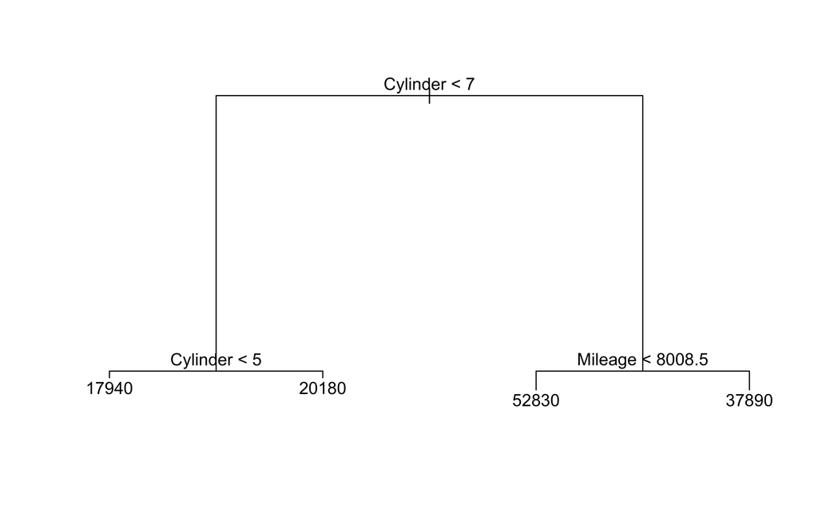

```r
#Figura da árvore
plot(modelo)
text(modelo)
```

```r
# Produzir previsões
previsao <- predict(modelo, dados_teste)
head(previsao)
```

```
       1        2        3        4        5        6
17938.65 17938.65 17938.65 17938.65 17938.65 17938.65
```

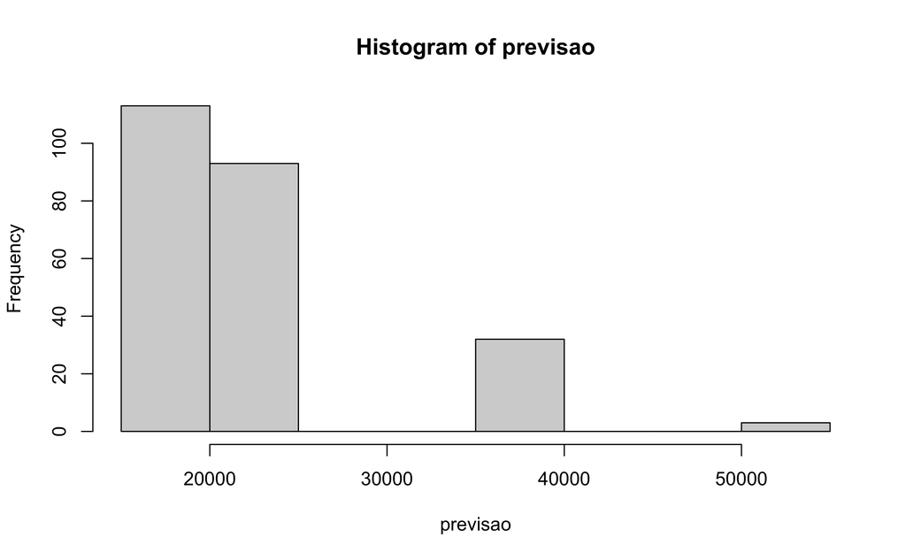

```r
hist(previsao)
```

Por fim as **medidas de acurácia**:

```r
# Calcular acurácia
forecast::accuracy(object = predict(modelo), x = dados_treino$Price)
```

```
                   ME     RMSE      MAE       MPE     MAPE
Test set 1.064657e-11 6995.447 5422.974 -10.14438 27.19621
```

```r
forecast::accuracy(object = previsao, x = dados_teste$Price)
```

```
                ME    RMSE      MAE       MPE     MAPE
Test set -550.4836 7203.96 5537.399 -13.39965 28.86222
```

## Notas de rodapé

[^1]: Todo este material foi retirado de diversas postagens da Análise Macro (www.analisemacro.com.br)
[^2]: Quando $\alpha = 0$, $T = T_0$.